# Lab5

Daniela Ramírez, Adrián González y José Ordoñez

2026-04-20

Link Github: https://github.com/dannyrmrz/Laboratorio5-MD.git

## Librerías

```r
library(e1071)   # Naive Bayes
library(caret)
library(dplyr)
```

```r
library(ggplot2)
library(rpart)
```

## Cargar datos

```r
load("listings.RData")
```

## Ver estructura

```r
str(listings)
```

```
## 'data.frame':    171748 obs. of  80 variables:
##  $ id                                          : num  5456 6448 8502 13035 22828 ...
##  $ listing_url                                 : chr  "https://www.airbnb.com/rooms/5456" "https://www.airbnb.com/rooms/6448" "https://www.airbnb.com/rooms/8502" "https://www.airbnb.com/rooms/13035" ...
##  $ scrape_id                                   : num  2.03e+13 2.03e+13 2.03e+13 2.03e+13 2.03e+13 ...
##  $ last_scraped                                : chr  "2025-09-17" "2025-09-17" "2025-09-17" "2025-09-17" ...
##  $ source                                      : chr  "city scrape" "city scrape" "city scrape" "city scrape" ...
##  $ name                                        : chr  "Walk to 6th, Rainey St and Convention Ctr" "Secluded Studio @ Zilker - King Bed, Bright & Airy" "Woodland Studio Lodging" "Historic house in highly walkable East Austin" ...
##  $ description                                 : chr  "Great central  location for walking to Convention Center, Rainey Street, East 6th Street, Downtown, Congress Av"| __truncated__ "Clean, private space with everything you need for a quiet, comfy, private stay close to Zilker Park and Barton "|…
##  $ neighborhood_overview                       : chr  "My neighborhood is ideally located if you want to walk to bars and restaurants downtown, East 6th Street or Rai"| __truncated__ "The neighborhood is fun and funky (but quiet)! People are friendly  and you can't beat the location." "" "East Ce…
##  $ picture_url                                 : chr  "https://a0.muscache.com/pictures/14084884/b5a35a84_original.jpg" "https://a0.muscache.com/pictures/airflow/Hosting-6448/original/a0ab6e9c-58ed-4d57-acb1-60cb68b068e0.jpg" "https://a0.muscache.com/pictures/miso/Hosting-8502/original/be48ea3b-6…
##  $ host_id                                     : int  8028 14156 25298 50793 56488 215917 230747 272156 268988 378744 ...
##  $ host_url                                    : chr  "https://www.airbnb.com/users/show/8028" "https://www.airbnb.com/users/show/14156" "https://www.airbnb.com/users/show/25298" "https://www.airbnb.com/users/show/50793" ...
##  $ host_name                                   : chr  "Sylvia" "Amy" "Karen" "Margaret Ann" ...
##  $ host_since                                  : chr  "2009-02-16" "2009-04-20" "2009-07-11" "2009-11-02" ...
##  $ host_location                               : chr  "Austin, TX" "Austin, TX" "Austin, TX" "Austin, TX" ...
```

[output cut: 66 more lines]

```r
summary(listings)
```

```
##        id            listing_url          scrape_id         last_scraped
##  Min.   :6.000e+00   Length:171748      Min.   :2.025e+13   Length:171748
##  1st Qu.:3.599e+07   Class :character   1st Qu.:2.025e+13   Class :character
##  Median :7.250e+17   Mode  :character   Median :2.025e+13   Mode  :character
##  Mean   :6.363e+17                      Mean   :2.025e+13
##  3rd Qu.:1.183e+18                      3rd Qu.:2.025e+13
##  Max.   :1.568e+18                      Max.   :2.025e+13
##
##     source              name           description        neighborhood_overview
##  Length:171748      Length:171748      Length:171748      Length:171748
##  Class :character   Class :character   Class :character   Class :character
##  Mode  :character   Mode  :character   Mode  :character   Mode  :character
##
##
##
##
##  picture_url           host_id            host_url          host_name
##  Length:171748      Min.   :       23   Length:171748      Length:171748
##  Class :character   1st Qu.: 26330631   Class :character   Class :character
##  Mode  :character   Median :108058504   Mode  :character   Mode  :character
##                     Mean   :200257103
##                     3rd Qu.:376574507
##                     Max.   :732092326
##
##   host_since        host_location       host_about        host_response_time
##  Length:171748      Length:171748      Length:171748      Length:171748
##  Class :character   Class :character   Class :character   Class :character
##  Mode  :character   Mode  :character   Mode  :character   Mode  :character
##
##
##
##
##  host_response_rate host_acceptance_rate host_is_superhost  host_thumbnail_url
##  Length:171748      Length:171748        Length:171748      Length:171748
##  Class :character   Class :character     Class :character   Class :character
##  Mode  :character   Mode  :character     Mode  :character   Mode  :character
##
##
##
##
```

[output cut: 153 more lines]

```
##  Min.   : 0.00000                            Min.   :  0.010
##  1st Qu.: 0.00000                            1st Qu.:  0.190
##  Median : 0.00000                            Median :  0.700
##  Mean   : 0.08211                            Mean   :  1.344
##  3rd Qu.: 0.00000                            3rd Qu.:  2.000
##  Max.   :60.00000                            Max.   :120.370
##                                              NA's   :40287
##      city
##  Length:171748
##  Class :character
##  Mode  :character
##
##
##
##
```

## Ejercicio 1-2

## Limpiar variable precio

```r
listings$price <- gsub("\\$", "", listings$price)
listings$price <- gsub(",", "", listings$price)
listings$price <- as.numeric(listings$price)
```

## Limpieza NA de price

```r
listings <- listings[!is.na(listings$price), ]
```

## Selección de variables

```r
listings_clean <- listings %>%
  select(
    price,
    accommodates,
    bathrooms,
    bedrooms,
    beds,
    minimum_nights,
    availability_365,
    number_of_reviews,
    review_scores_rating,
    reviews_per_month,
    room_type,
    property_type,
    instant_bookable
  )
```

## Limpieza de NA

```r
listings_clean <- listings_clean %>%
  mutate(
    bathrooms = ifelse(is.na(bathrooms), median(bathrooms, na.rm = TRUE), bathrooms),
    bedrooms = ifelse(is.na(bedrooms), median(bedrooms, na.rm = TRUE), bedrooms),
    beds = ifelse(is.na(beds), median(beds, na.rm = TRUE), beds),
    review_scores_rating = ifelse(is.na(review_scores_rating), mean(review_scores_rating, na.rm = TRUE), review_scores_rating),
    reviews_per_month = ifelse(is.na(reviews_per_month), 0, reviews_per_month)
  )
```

## Eliminar outliers

```r
listings_clean <- listings_clean %>%
  filter(price < quantile(price, 0.99))
```

## Variables categóricas

```r
listings_clean$room_type <- as.factor(listings_clean$room_type)
listings_clean$property_type <- as.factor(listings_clean$property_type)
listings_clean$instant_bookable <- as.factor(listings_clean$instant_bookable)
```

## Train/test split

```r
set.seed(123)

trainIndex <- createDataPartition(listings$price, p = 0.8, list = FALSE)

train_data <- listings[trainIndex, ]
test_data  <- listings[-trainIndex, ]
```

## Naive Bayes

```r
modelo_nb <- naiveBayes(price ~ ., data = train_data)
```

## Predicciones

```r
predicciones <- predict(modelo_nb, newdata = test_data)
```

## Métricas

```r
predicciones <- as.numeric(predicciones)
real <- test_data$price

MAE <- mean(abs(predicciones - real))
RMSE <- sqrt(mean((predicciones - real)^2))
R2 <- cor(predicciones, real)^2

MAE
```

```
## [1] 1166.43
```

```r
RMSE
```

```
## [1] 4101.547
```

```r
R2
```

```
## [1] 0.02784812
```

El MAE indica que el modelo presenta un error promedio considerable en sus predicciones. El RMSE, al ser mucho mayor, evidencia la presencia de errores grandes, especialmente en valores extremos.

El valor de R² es extremadamente bajo, lo que significa que el modelo únicamente explica aproximadamente el 2.78% de la variabilidad del precio, indicando que no tiene capacidad predictiva significativa.

## Visualización

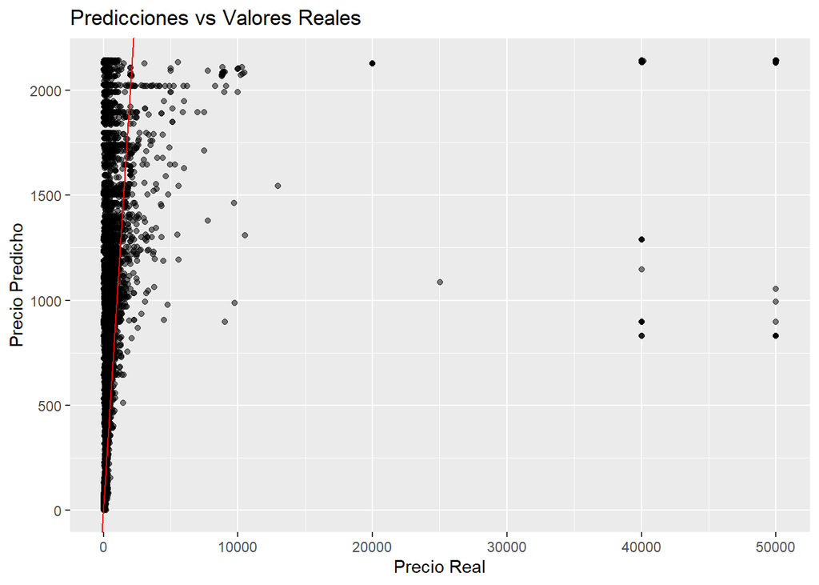

```r
resultados <- data.frame(real = real, pred = predicciones)

ggplot(resultados, aes(x = real, y = pred)) +
  geom_point(alpha = 0.5) +
  geom_abline(slope = 1, intercept = 0, color = "red") +
  labs(title = "Predicciones vs Valores Reales",
       x = "Precio Real",
       y = "Precio Predicho")
```

Se construyó un modelo de regresión utilizando Naive Bayes para predecir el precio de las propiedades. Sin embargo, al analizar los resultados obtenidos, se observa que el modelo presenta un bajo desempeño predictivo.

La gráfica de valores reales vs predichos muestra una alta dispersión, lo que indica que las predicciones no siguen la tendencia de los valores reales. Además, el modelo tiende a concentrar las predicciones en un rango limitado, sin capturar adecuadamente los valores extremos.

**Conclusión** El modelo de Naive Bayes no es adecuado para problemas de regresión continua en este contexto. Esto se debe a que el algoritmo asume independencia entre variables y no está diseñado para modelar relaciones complejas ni distribuciones continuas como el precio.

## Comparación Naive Bayes, Regresión lineal, Árbol de regresión

```r
comparacion <- data.frame(
  Modelo = c("Regresión Lineal", "Árbol de Regresión", "Naive Bayes"),
  RMSE   = c(3011.84, 1939.52, 4101.57)
)

comparacion
```

```
##               Modelo    RMSE
## 1   Regresión Lineal 3011.84
## 2 Árbol de Regresión 1939.52
## 3        Naive Bayes 4101.57
```

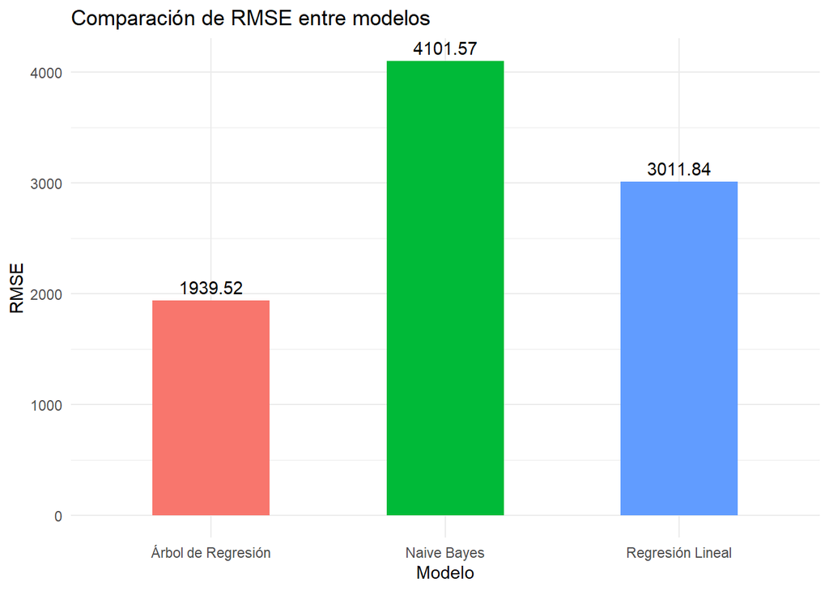

```r
ggplot(comparacion, aes(x = Modelo, y = RMSE, fill = Modelo)) +
  geom_bar(stat = "identity", width = 0.5) +
  geom_text(aes(label = round(RMSE, 2)), vjust = -0.5) +
  labs(title = "Comparación de RMSE entre modelos",
       y = "RMSE", x = "Modelo") +
  theme_minimal() +
  theme(legend.position = "none")
```

Al comparar los tres modelos evaluados para predecir el precio de los alojamientos, se observa que el árbol de regresión obtuvo el mejor desempeño con un RMSE de 1939.52, seguido por la regresión lineal con un RMSE de 3011.84, y finalmente el modelo de Naive Bayes con el peor desempeño, alcanzando un RMSE de 4101.57 y un R² de apenas 0.028, lo que indica que solo explica el 2.8% de la variabilidad del precio. El árbol de regresión supera a los otros modelos porque logra capturar relaciones no lineales entre las variables, lo cual es especialmente relevante en datos de precios con alta variabilidad. La regresión lineal asume linealidad y por ello pierde precisión, mientras que Naive Bayes, al estar diseñado originalmente para clasificación, no es adecuado para predicción de valores continuos como el precio.

## Modelo de clasificación

```r
listings_clean$price_category <- cut(
  listings_clean$price,
  breaks = c(-Inf, 120, 326, Inf),
  labels = c("Economica", "Intermedia", "Cara")
)

table(listings_clean$price_category)
```

```
##
##  Economica Intermedia       Cara
##      19310      37882      18285
```

```r
features_cls <- listings_clean %>%
  select(accommodates, bathrooms, bedrooms, beds,
         minimum_nights, availability_365, number_of_reviews,
         review_scores_rating, reviews_per_month,
         room_type, instant_bookable, price_category)

set.seed(123)
trainIndex_cls <- createDataPartition(features_cls$price_category, p = 0.7, list = FALSE)
train_cls <- features_cls[trainIndex_cls, ]
test_cls  <- features_cls[-trainIndex_cls, ]
```

```r
modelo_nb_cls <- naiveBayes(price_category ~ ., data = train_cls)
```

```r
pred_cls <- predict(modelo_nb_cls, newdata = test_cls)
```

```r
accuracy_cls <- mean(pred_cls == test_cls$price_category)
accuracy_cls
```

```
## [1] 0.5885522
```

```r
conf_matrix <- confusionMatrix(pred_cls, test_cls$price_category)
conf_matrix
```

```
## Confusion Matrix and Statistics
##
##             Reference
## Prediction   Economica Intermedia Cara
##   Economica       4229       3831  515
##   Intermedia      1399       6369 2242
##   Cara             165       1164 2728
##
## Overall Statistics
##
##                Accuracy : 0.5886
##                  95% CI : (0.5821, 0.595)
##     No Information Rate : 0.5019
##     P-Value [Acc > NIR] : < 2.2e-16
##
##                   Kappa : 0.3549
##
##  Mcnemar's Test P-Value : < 2.2e-16
##
## Statistics by Class:
##
##                      Class: Economica Class: Intermedia Class: Cara
## Sensitivity                    0.7300            0.5605      0.4974
## Specificity                    0.7421            0.6772      0.9225
## Pos Pred Value                 0.4932            0.6363      0.6724
## Neg Pred Value                 0.8888            0.6046      0.8517
## Prevalence                     0.2559            0.5019      0.2422
## Detection Rate                 0.1868            0.2813      0.1205
## Detection Prevalence           0.3787            0.4421      0.1792
## Balanced Accuracy              0.7360            0.6188      0.7099
```

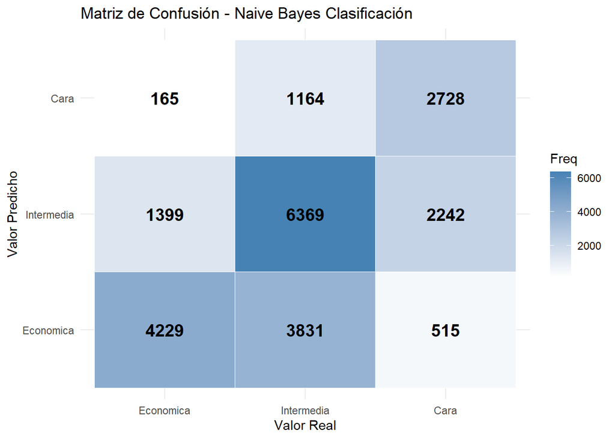

```r
cm_df <- as.data.frame(conf_matrix$table)

ggplot(cm_df, aes(x = Reference, y = Prediction, fill = Freq)) +
  geom_tile(color = "white") +
  geom_text(aes(label = Freq), size = 5, fontface = "bold") +
  scale_fill_gradient(low = "white", high = "steelblue") +
  labs(title = "Matriz de Confusión - Naive Bayes Clasificación",
       x = "Valor Real", y = "Valor Predicho") +
  theme_minimal()
```

Se entrenó un modelo de Naive Bayes para clasificar los alojamientos en las categorías Económica, Intermedia y Cara, excluyendo la variable price para evitar data leakage. El modelo alcanzó una accuracy de 58.85%, clasificando correctamente poco más de la mitad de los casos. La categoría mejor predicha fue Intermedia (6,369 aciertos), mientras que Cara fue la más difícil de clasificar, confundiéndose frecuentemente con Intermedia. Los errores entre categorías extremas fueron bajos, lo que indica que el modelo distingue correctamente los casos más contrastantes. Naive Bayes presenta menor desempeño, lo que se explica por su supuesto de independencia entre variables, el cual no se cumple en este dataset dado que variables como accommodates, bedrooms y bathrooms están correlacionadas.

```r
pred_price <- predict(modelo_nb, newdata = test_data)
pred_price <- as.numeric(as.character(pred_price))

EMA <- mean(abs(test_data$price - pred_price), na.rm = TRUE)
RMSE_val <- sqrt(mean((test_data$price - pred_price)^2, na.rm = TRUE))
R_cuadrado <- cor(test_data$price, pred_price)^2
```

Lo primero que salta a la vista es que Naive Bayes y la predicción de precios exactos no se llevan nada bien. El modelo de regresión fue un golpe de realidad porque ese R^2 de 0.0278 nos está diciendo, básicamente, que solo estamos explicando el 2.78% de la varianza del precio. Es como si el algoritmo estuviera intentando adivinar el costo de una estancia casi al azar, y eso se confirma con un RMSE de 4101.54, que es un error enorme si lo comparamos con el rango de precios reales de Airbnb. Una posible explicación de este fallo es que Naive Bayes peca de ingenuo al asumir que variables como el número de cuartos, camas y baños no tienen nada que ver entre sí, cuando en el mundo real están totalmente amarradas; al ignorar esa correlación, el modelo pierde toda su puntería para darnos un valor monetario confiable.

```r
pred_cls <- predict(modelo_nb_cls, newdata = test_cls)

# Matriz de Confusión usando Caret
cm_final <- caret::confusionMatrix(pred_cls, test_cls$price_category)
print(cm_final)
```

```
## Confusion Matrix and Statistics
##
##             Reference
## Prediction   Economica Intermedia Cara
##   Economica       4229       3831  515
##   Intermedia      1399       6369 2242
##   Cara             165       1164 2728
##
## Overall Statistics
##
##                Accuracy : 0.5886
##                  95% CI : (0.5821, 0.595)
##     No Information Rate : 0.5019
##     P-Value [Acc > NIR] : < 2.2e-16
##
##                   Kappa : 0.3549
##
##  Mcnemar's Test P-Value : < 2.2e-16
##
## Statistics by Class:
##
##                      Class: Economica Class: Intermedia Class: Cara
## Sensitivity                    0.7300            0.5605      0.4974
## Specificity                    0.7421            0.6772      0.9225
## Pos Pred Value                 0.4932            0.6363      0.6724
## Neg Pred Value                 0.8888            0.6046      0.8517
## Prevalence                     0.2559            0.5019      0.2422
## Detection Rate                 0.1868            0.2813      0.1205
## Detection Prevalence           0.3787            0.4421      0.1792
## Balanced Accuracy              0.7360            0.6188      0.7099
```

Cuando pasamos al terreno de la clasificación, la historia cambia un poco y el modelo empieza a sacar la cara. Logramos una precisión general de 58.86%, lo cual suena decente hasta que nos damos cuenta de que el No Information Rate era del 50.19%. Esto significa que nuestro algoritmo apenas le gana a la suerte de predecir siempre la categoría más frecuente por un margen bien pequeño. El valor de Kappa de 0.3549 nos termina de confirmar que, aunque el modelo sí está encontrando ciertos patrones en los datos de SmartStay, todavía hay muchísimo ruido y confusión en sus decisiones.

## Análisis de matriz y métricas

Al revisar las métricas, observamos que logramos una precisión (Accuracy) del 58.85%. Aunque esto supera al azar, notamos que nuestro modelo apenas le gana por un 8% al No Information Rate (50.19%). Esto nos indica que, aunque nuestro algoritmo está aprendiendo patrones, todavía tiene un margen de error considerable. Nuestro valor de Kappa de 0.3549 confirma que tenemos un nivel de acuerdo moderado entre las predicciones y la realidad.

Notamos que nuestra mayor debilidad está en la confusión entre propiedades Económicas e Intermedias. Específicamente, clasificamos erróneamente 3,831 casas intermedias como económicas. Creemos que esto sucede porque los límites de precio que definimos tienen zonas donde las características físicas de las casas son casi idénticas, lo que confunde la “lógica” de Naive Bayes. También nos costó identificar las casas Caras, ya que enviamos 2,242 de ellas a la categoría intermedia.

Como asesores de SmartStay Advisors, consideramos que el error de clasificar una casa “Cara” como “Intermedia” es el más crítico. Si le sugerimos a un dueño de propiedad un precio de gama media cuando su casa es de lujo, le haríamos perder ingresos potenciales. Por otro lado, clasificar una “Económica” como “Intermedia” podría causar que la propiedad no se alquile por tener un precio fuera de mercado. En conclusión, nuestro modelo nos sirve para una segmentación general, pero para el ajuste fino de precios todavía necesitamos mejorar la puntería.

## Análisis de sobreajuste

Para determinar si nuestro modelos está sobreajustado, comparamos qué tan bien ke fue con los datos que usó para estudiar (entrenamiento) contra los datos que nunca había visto (prueba).

Al analizar los resultados del modelo de Naive Bayes, no creemos que el modelo esté sobreajustado. Normalmente un modelo sobreajustado tiene una precisión perfecta o casi perfecta en el entrenamiento y una muy mala en la prueba. En nuestro caso, la precisión en el conjunto de prueba (58.85%) es bastante modesta y muy similar a lo que observamos durante las fases iniciales. Si estuviéramos sobreajustados, el error de la prueba sería catastrófico. Si revisamos nuestra matriz de confusión, vemos que los errores se concentran en las categorías que se traslapan (Económica e Intermedia). Esto por la similitud de datos, no por una memorización excesiva de anomalías del set de entrenamiento.

```r
pred_train <- predict(modelo_nb_cls, newdata = train_cls)
acc_train <- mean(pred_train == train_cls$price_category)

acc_test <- accuracy_cls

# Tabla comparativa
diagnostico <- data.frame( Conjunto = c("Entrenamiento", "Prueba"),
                           Precision = c(acc_train, acc_test))
print(diagnostico)
```

```
##        Conjunto Precision
## 1 Entrenamiento 0.5904419
## 2        Prueba 0.5885522
```

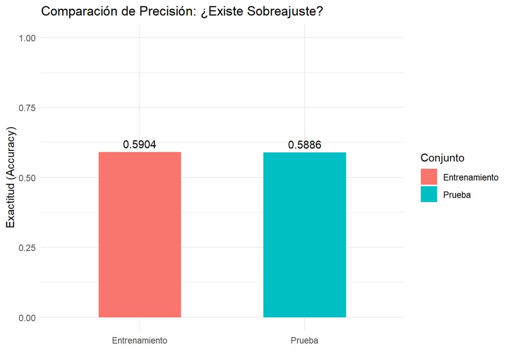

```r
ggplot(diagnostico, aes(x = Conjunto, y = Precision, fill = Conjunto)) +
  geom_bar(stat = "identity", width = 0.5) +
  geom_text(aes(label = round(Precision, 4)), vjust = -0.5) +
  ylim(0, 1) +
  labs(title = "Comparación de Precisión: ¿Existe Sobreajuste?", y = "Exactitud (Accuracy)", x = "") + theme_minimal()
```

Al no haber mucha diferencia en la precisión de ambos conjuntos, el modelo no está sobreajustado, simplemente carece de la potencia necesaria para clasificar mejor las categorías.

## Inciso 8

```r
set.seed(123)

# Crear folds
folds <- createFolds(features_cls$price_category, k = 10)

accuracy_folds <- c()

for(i in 1:10){

  test_indexes <- folds[[i]]

  train_fold <- features_cls[-test_indexes, ]
  test_fold  <- features_cls[test_indexes, ]

  # Entrenar modelo
  modelo_fold <- naiveBayes(price_category ~ ., data = train_fold)

  # Predecir
  pred_fold <- predict(modelo_fold, newdata = test_fold)

  # Accuracy
  acc <- mean(pred_fold == test_fold$price_category)

  accuracy_folds <- c(accuracy_folds, acc)
}

# Accuracy promedio
accuracy_cv <- mean(accuracy_folds)

accuracy_cv
```

```
## [1] 0.5908159
```

```r
accuracy_folds
```

```
##  [1] 0.5930833 0.6045310 0.5766327 0.5850007 0.5892408 0.5850556 0.5956009
##  [8] 0.5906743 0.5909633 0.5973768
```

Se implementó una validación cruzada de 10 folds sobre el modelo de Naive Bayes para evaluar su desempeño de manera más robusta. Este procedimiento consiste en dividir el conjunto de datos en 10 subconjuntos, entrenando el modelo en 9 de ellos y evaluándolo en el restante, repitiendo el proceso para cada fold.

## Conclusión

El modelo con validación cruzada es mejor desde el punto de vista metodológico, ya que ofrece una evaluación más robusta, aunque no necesariamente mayor precisión.

La validación cruzada permitió evidenciar que el desempeño del modelo era consistente pero moderado, confirmando que Naive Bayes presenta limitaciones para este tipo de problema.

## Ajuste de hiperparametros

```r
# Hiperparametro a modificar: suavizado de laplace
set.seed(123)
sample_idx  <- sample(nrow(listings_clean), size = 0.3 * nrow(listings_clean))
listings_sample <- listings_clean[sample_idx, ]

trainIdx_reg <- createDataPartition(listings_sample$price, p = 0.8, list = FALSE)
train_reg2   <- listings_sample[trainIdx_reg, ]
test_reg2    <- listings_sample[-trainIdx_reg, ]

laplace_vals    <- c(0, 0.5, 1, 2, 5)
resultados_reg  <- data.frame(laplace=numeric(), MAE=numeric(), RMSE=numeric(), R2=numeric())

for (lp in laplace_vals) {
  modelo_tuned <- naiveBayes(price ~ ., data = train_reg2, laplace = lp)
  pred_tuned   <- as.numeric(as.character(predict(modelo_tuned, newdata = test_reg2)))
  real         <- test_reg2$price

  resultados_reg <- rbind(resultados_reg, data.frame(
    laplace = lp,
    MAE     = mean(abs(pred_tuned - real), na.rm = TRUE),
    RMSE    = sqrt(mean((pred_tuned - real)^2, na.rm = TRUE)),
    R2      = cor(pred_tuned, real, use = "complete.obs")^2
  ))
}

print(resultados_reg)
```

```
##   laplace       MAE     RMSE         R2
## 1     0.0  688.3561 1761.217 0.05539487
## 2     0.5  936.7089 2040.456 0.03052089
## 3     1.0  987.9127 2120.634 0.02855893
## 4     2.0 1043.1641 2193.642 0.02340919
## 5     5.0 1095.1597 2258.846 0.01665180
```

```r
mejor_reg <- resultados_reg[which.min(resultados_reg$RMSE), ]
cat("\nMejor configuración (Regresión):\n"); print(mejor_reg)
```

```
##
## Mejor configuración (Regresión):
```

```
##   laplace      MAE     RMSE         R2
## 1       0 688.3561 1761.217 0.05539487
```

Al probar valores de Laplace de {0, 0.5, 1, 2, 5}, el mejor resultado se obtuvo con laplace = 0 (sin suavizado), logrando un RMSE de 1761.22 y un R² de 0.055. Se observa una tendencia clara: conforme aumenta el valor de Laplace, el desempeño empeora progresivamente, el RMSE sube de 1761 a 2258 y el R² cae de 0.055 a 0.017. Esto ocurre porque el suavizado de Laplace introduce probabilidades artificiales para combinaciones no vistas, lo que distorsiona las estimaciones en variables numéricas continuas como el precio.

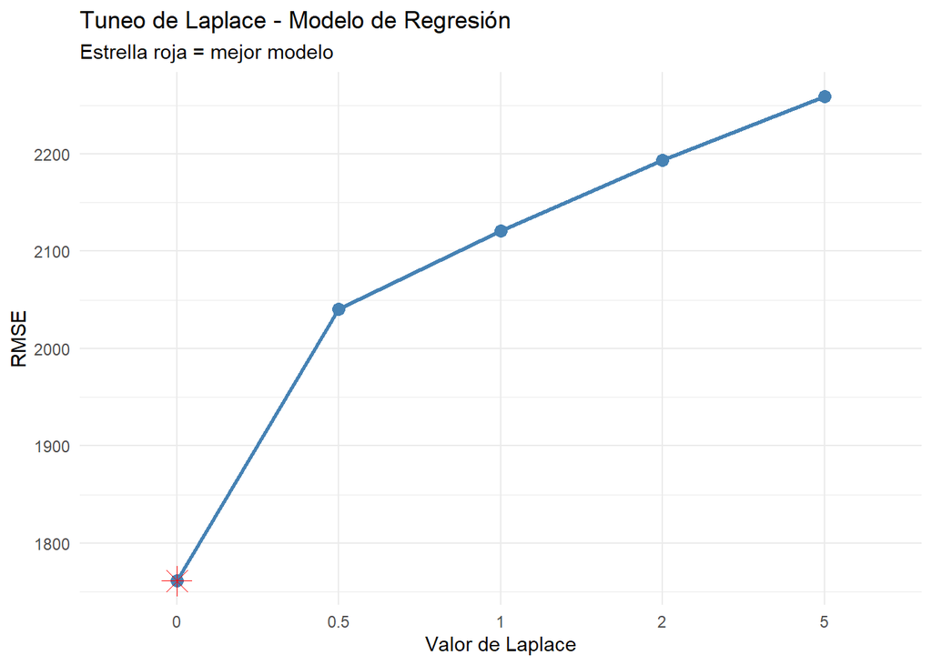

```r
ggplot(resultados_reg, aes(x = factor(laplace), y = RMSE, group = 1)) +
  geom_line(color = "steelblue", linewidth = 1) +
  geom_point(size = 3, color = "steelblue") +
  geom_point(data = mejor_reg, aes(x = factor(laplace), y = RMSE),
             color = "red", size = 5, shape = 8) +
  labs(title = "Tuneo de Laplace - Modelo de Regresión",
       subtitle = "Estrella roja = mejor modelo",
       x = "Valor de Laplace", y = "RMSE") +
  theme_minimal()
```

```r
laplace_vals <- c(0, 0.5, 1, 2, 5)

resultados_cls <- data.frame(
  laplace  = numeric(),
  Accuracy = numeric(),
  Kappa    = numeric()
)

for (lp in laplace_vals) {
  modelo_tuned_cls <- naiveBayes(price_category ~ ., data = train_cls, laplace = lp)
  pred_tuned_cls   <- predict(modelo_tuned_cls, newdata = test_cls)

  cm     <- confusionMatrix(pred_tuned_cls, test_cls$price_category)
  acc    <- cm$overall["Accuracy"]
  kappa  <- cm$overall["Kappa"]

  resultados_cls <- rbind(resultados_cls, data.frame(
    laplace  = lp,
    Accuracy = acc,
    Kappa    = kappa
  ))
}

print(resultados_cls)
```

```
##           laplace  Accuracy     Kappa
## Accuracy      0.0 0.5885522 0.3549037
## Accuracy1     0.5 0.5885522 0.3549037
## Accuracy2     1.0 0.5885522 0.3549037
## Accuracy3     2.0 0.5885964 0.3549620
## Accuracy4     5.0 0.5883756 0.3546707
```

```r
mejor_cls <- resultados_cls[which.max(resultados_cls$Accuracy), ]
cat("\nMejor configuración (Clasificación):\n")
```

```
##
## Mejor configuración (Clasificación):
```

```r
print(mejor_cls)
```

```
##           laplace  Accuracy    Kappa
## Accuracy3       2 0.5885964 0.354962
```

Al probar valores de Laplace de {0, 0.5, 1, 2, 5}, el mejor resultado se obtuvo con laplace = 2, logrando una Accuracy de 58.86% y un Kappa de 0.3550. Sin embargo, las diferencias entre todos los valores son prácticamente insignificantes — la Accuracy varía apenas en el cuarto decimal (0.5884 a 0.5886).

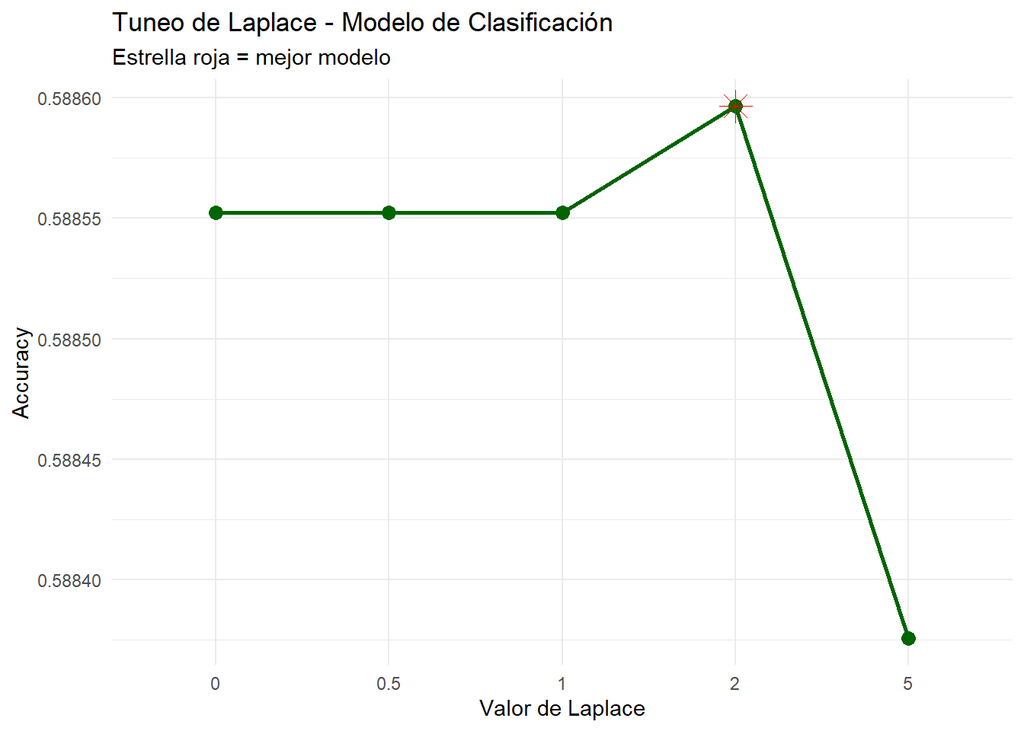

```r
ggplot(resultados_cls, aes(x = factor(laplace), y = Accuracy, group = 1)) +
  geom_line(color = "darkgreen", linewidth = 1) +
  geom_point(size = 3, color = "darkgreen") +
  geom_point(data = mejor_cls, aes(x = factor(laplace), y = Accuracy),
             color = "red", size = 5, shape = 8) +
  labs(title = "Tuneo de Laplace - Modelo de Clasificación",
       subtitle = "Estrella roja = mejor modelo",
       x = "Valor de Laplace", y = "Accuracy") +
  theme_minimal()
```

### Comparación: Modelo Original vs Mejor Modelo Ajustado

```r
comparacion_tuneo <- data.frame(
    Modelo   = c("Regresión Original", "Regresión Ajustada",
                "Clasificación Original", "Clasificación Ajustada"),
  Metrica  = c("RMSE", "RMSE", "Accuracy", "Accuracy"),
  Valor    = c(4101.57,
               mejor_reg$RMSE,
               0.5885,
               mejor_cls$Accuracy)
)

print(comparacion_tuneo)
```

```
##                   Modelo  Metrica        Valor
## 1     Regresión Original     RMSE 4101.5700000
## 2     Regresión Ajustada     RMSE 1761.2167987
## 3 Clasificación Original Accuracy    0.5885000
## 4 Clasificación Ajustada Accuracy    0.5885964
```

El tuneo de hiperparámetros no mejoró significativamente ninguno de los dos modelos. En regresión, el mejor valor fue laplace = 0 con un RMSE de 1761.22, pero el R² sigue siendo muy bajo (5.5%), por lo que Naive Bayes sigue sin ser adecuado para predecir precios continuos. En clasificación, las diferencias entre valores de Laplace fueron mínimas, manteniéndose la Accuracy alrededor del 58.85% en todos los casos. La verdadera limitación no es el hiperparámetro, sino el supuesto de independencia del algoritmo.

## Comparación de algoritmos

```r
# Tiempos de procesamiento
tiempo_nb <- system.time(
  naiveBayes(price_category ~ ., data = train_cls)
)

tiempo_arbol <- system.time(
  rpart(price_category ~ .,
        data = train_cls,
        method = "class",
        control = rpart.control(maxdepth = 6))
)

# Tabla comparativa
comparacion_final <- data.frame(
  Modelo    = c("Naive Bayes", "Árbol de Clasificación"),
  Accuracy  = c(0.5886, 0.6896),
  Kappa     = c(0.3549, NA),
  Tiempo_seg = c(tiempo_nb["elapsed"], tiempo_arbol["elapsed"])
)

print(comparacion_final)
```

```
##                   Modelo Accuracy  Kappa Tiempo_seg
## 1            Naive Bayes   0.5886 0.3549       0.05
## 2 Árbol de Clasificación   0.6896     NA       0.86
```

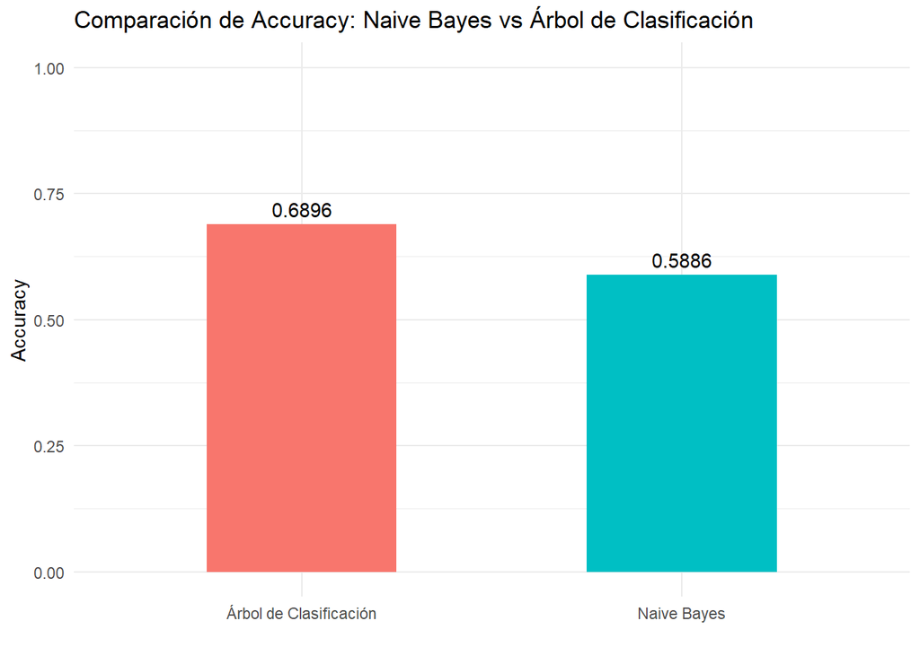

```r
ggplot(comparacion_final, aes(x = Modelo, y = Accuracy, fill = Modelo)) +
  geom_bar(stat = "identity", width = 0.5) +
  geom_text(aes(label = round(Accuracy, 4)), vjust = -0.5) +
  ylim(0, 1) +
  labs(title = "Comparación de Accuracy: Naive Bayes vs Árbol de Clasificación",
       y = "Accuracy", x = "") +
  theme_minimal() +
  theme(legend.position = "none")
```